# Holger Russ scRNA-Seq analysis

Kent Riemondy RBI

## Experiment Summary

| Sample | Description |
| --- | --- |
| BNLx | BNLx Strain |
| SHR | SHR Strain |

```r
samples <- c(
  "BNLx_merged",
  "SHR_merged")

sample_paths <- file.path(data_dir ,
                          samples)

names(sample_paths) <- samples

bcells <- Seurat::Read10X(sample_paths)
```

```r
bcells <- CreateSeuratObject(counts = bcells,
                              min.cells = 3,
                              min.genes = 200,
                              project = "Saba",
                              names.field = c(1,2),
                              names.delim = "_")
```

```r
# add correct sample identifier
ids <- colnames(bcells@assays$RNA@data)
ids <- str_split(ids, "_[ATCG]{10}", simplify = T) %>% .[, 1]
ids <- data.frame(row.names = colnames(bcells@assays$RNA@data),
                  expt = ids)
bcells <- AddMetaData(bcells, ids)
```

## QC Metrics

```r
summary_dat <- data_frame(cell = colnames(bcells@assays$RNA@data),
                          expt = bcells@meta.data$expt,
                          nUMIs = colSums(as.matrix(bcells@assays$RNA@data)),
                          nGenes = colSums(as.matrix(bcells@assays$RNA@data) > 0))

summary_dat <- summary_dat %>%
  group_by(expt) %>%
  dplyr::arrange(desc(nUMIs))

n_cells <- summary_dat %>%
  group_by(expt) %>%
  summarize(n_cells = n(),
            median_UMIs = median(nUMIs),
            median_Genes = median(nGenes))

knitr::kable(n_cells,
             caption = "Number of cells prior to filtering and summary statistics")
```

Number of cells prior to filtering and summary statistics

| expt | n_cells | median_UMIs | median_Genes |
| --- | --- | --- | --- |
| BNLx_merged | 3253 | 38004 | 6542 |
| SHR_merged | 1884 | 19178 | 4951 |

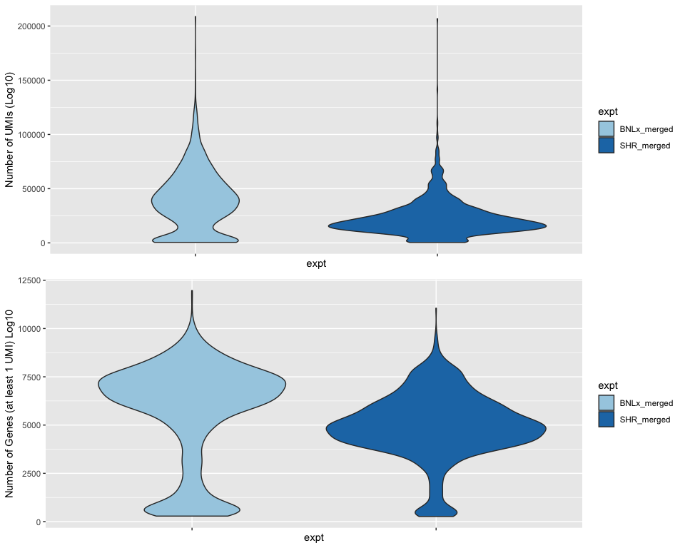

```r
a <- ggplot(summary_dat, aes(expt, nUMIs)) +
  geom_violin(aes(fill = expt)) +
  scale_fill_brewer(palette = "Paired") +
  ylab("Number of UMIs (Log10)") +
  theme(axis.text.x = element_blank())

b <- ggplot(summary_dat, aes(expt, nGenes)) +
    geom_violin(aes(fill = expt)) +
  scale_fill_brewer(palette = "Paired") +
  ylab("Number of Genes (at least 1 UMI) Log10") +
  theme(axis.text.x = element_blank())
plot_grid(a, b, ncol = 1)
```

```r
dir.create("/Users/smithh/Documents/Saba_Lab/cellranger_results/count_matrix", showWarnings = FALSE)

write.table(as.matrix(bcells@assays$RNA@data),
            file.path("/Users/smithh/Documents/Saba_Lab/cellranger_results/count_matrix", "all_samples_raw_counts_matrix.txt"),
            quote = F, sep = "\t")

gzip(file.path("/Users/smithh/Documents/Saba_Lab/cellranger_results/count_matrix",
               "all_samples_raw_counts_matrix.txt"),
     overwrite = TRUE,
     remove = TRUE)
```

```r
cell_counts <- function(seurat_object){
  #returns tbl_df with number of cells per sample type in seurat object
  map_df(levels(seurat_object@ident),
         ~data_frame(sample = .x,
                     n_cells = length(WhichCells(seurat_object, ident = .x))))
}
```

## Mitochondrial Reads

The percentage of reads aligning to mitochondria is often an indicator of cell quality. Cells that have lysed prior to capture preferentially retain mitochondial RNA, but lose cellular cytoplasmic mRNA. As shown below there is a strong negative correlation with the number of UMIs and the proportion of reads aligning to mitochondria. Cells with less than 20% mitochondrial reads will be retained for further analysis.

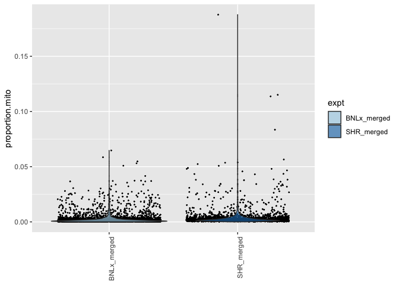

```r
# there are not unique IDs for mito genes in refseq, so I  am using this gene list

mito_gene_list <- c("ATP6", "ATP8", "COX1", "COX2", "COX3", "CYTB", "ND1", "ND2", "ND3", "ND4", "ND4L", "ND5", "ND6")
mito_gene_list <- paste0(mito_gene_list, collapse = "|")

mito.genes <- grep(mito_gene_list, rownames(bcells@assays$RNA@data), value = T)
proportion.mito <- Matrix::colSums(bcells@assays$RNA@data[mito.genes, ]) /
  Matrix::colSums(bcells@assays$RNA@data)

bcells <- AddMetaData(bcells, proportion.mito, "proportion.mito")

bcells[["percent.mt"]] <- PercentageFeatureSet(bcells, pattern = mito_gene_list)

unfiltered <- bcells@meta.data %>%
  tibble::rownames_to_column("cell") %>%
  left_join(summary_dat, by = c("cell", "expt")) %>%
  as_data_frame()

ggplot(unfiltered, aes(expt,
                       proportion.mito)) +
  geom_jitter(size = 0.25) +
  geom_violin(aes(fill = expt), alpha = 0.66) +
  scale_fill_brewer(palette = "Paired") +
  theme(
    axis.text.x = element_text(angle = 90, hjust = 1),
    axis.title.x = element_blank()
  )
```

### All Samples

```r
# ggplot(unfiltered,
#        aes(nUMI, proportion.mito)) +
#   geom_point(aes(color = expt)) +
#   scale_color_brewer(palette = "Paired")
```

```r
sample_names <- as.character(unique(bcells@meta.data$expt))
per_sample <- map(sample_names, ~filter(unfiltered,
                                        expt == .x))

# generate tab with individual plot programmatically
# see https://stackoverflow.com/questions/43752095/programmatically-insert-header-and-plot-in-same-code-chunk-with-r-markdown-using?noredirect=1&lq=1

for(i in seq_along(per_sample)){
  .col <- brewer.pal(10, "Paired")[i]
  cat('\n### ', sample_names[i], '\n')
  p <- ggplot(per_sample[[i]], aes(nUMIs, proportion.mito)) +
        geom_point(aes(color = expt)) +
        scale_color_manual(values = .col)
  print(p)
  cat('\n')
}
```

### BNLx_merged

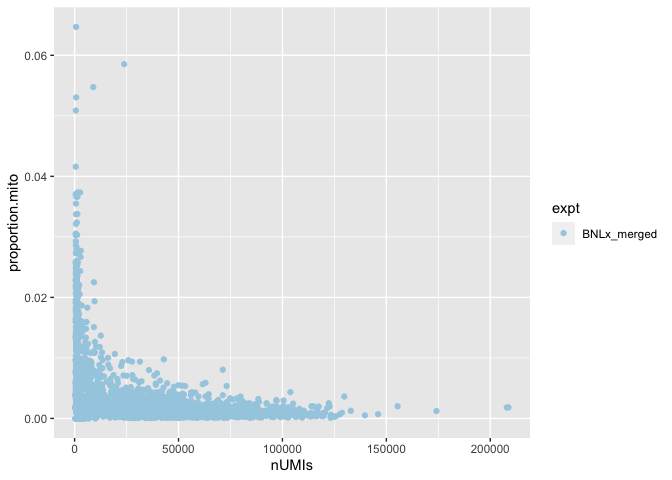

### SHR_merged

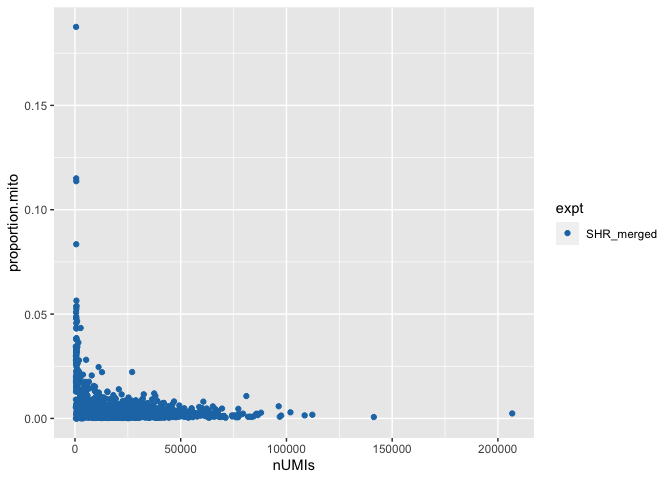

```r
# Visualize QC metrics as a violin plot
for(i in seq_along(per_sample)){
  .col <- brewer.pal(10, "Paired")[i]
  cat('\n### ', sample_names[i], '\n')
  print(VlnPlot(bcells, features = c("nFeature_RNA", "nCount_RNA", "percent.mt"), ncol = 3))
  cat('\n')
}
```

[output not shown]